# DATA550_Final_Project

Emma Dunne

2026-03-24

## Introduction

This analysis uses the Vitamin Deficiency Disease Prediction dataset (n = 4,000) to examine how demographic characteristics, lifestyle factors, dietary intake patterns, clinical symptoms, and laboratory values relate to vitamin/mineral deficiency diseases. Outcomes include multiple deficiency-related conditions (Anemia, Scurvy, Rickets Osteomalacia, Night Blindness) as well as a healthy reference group. The analysis includes a summary of key predictors to describe the study population and to evaluate data quality and distributions. A stacked bar chart diet type by disease status is also included to visualize differences in the proportion of healthy versus diseased participants across dietary patterns.These analyses aim to clarify which factors best differentiate nutritional deficiency conditions and to highlight patterns that could support earlier identification of individuals at elevated risk for disease.

## Table 1

| **Characteristic** | **Overall** N = 4,000<sup>1</sup> | **Disease status** **Healthy** N = 1,509<sup>1</sup> | **Disease status** **Diseased** N = 2,491<sup>1</sup> | **p-value**<sup>2</sup> |  |
| --- | --- | --- | --- | --- | --- |
| Age (years) | 51 (19) | 51 (19) | 50 (19) |  | 0.064 |
| Gender |  |  |  | 0.9 |  |
| Female | 1,971 (49%) | 746 (49%) | 1,225 (49%) |  |  |
| Male | 2,029 (51%) | 763 (51%) | 1,266 (51%) |  |  |
| BMI | 26.1 (4.9) | 25.9 (4.9) | 26.2 (4.9) | 0.060 |  |
| Exercise level |  |  |  | 0.5 |  |
| Active | 981 (25%) | 385 (26%) | 596 (24%) |  |  |
| Light | 996 (25%) | 367 (24%) | 629 (25%) |  |  |
| Moderate | 990 (25%) | 361 (24%) | 629 (25%) |  |  |
| Sedentary | 1,033 (26%) | 396 (26%) | 637 (26%) |  |  |
| Diet type |  |  |  | <0.001 |  |
| Omnivore | 993 (25%) | 575 (38%) | 418 (17%) |  |  |
| Pescatarian | 991 (25%) | 553 (37%) | 438 (18%) |  |  |
| Vegan | 1,017 (25%) | 20 (1.3%) | 997 (40%) |  |  |
| Vegetarian | 999 (25%) | 361 (24%) | 638 (26%) |  |  |
| Vitamin A (% RDA) | 91 (37) | 107 (36) | 81 (34) | <0.001 |  |
| Vitamin C (% RDA) | 89 (38) | 105 (36) | 80 (35) | <0.001 |  |
| Vitamin D (% RDA) | 72 (43) | 101 (43) | 54 (31) | <0.001 |  |
| Vitamin B12 (% RDA) | 63 (37) | 94 (32) | 44 (26) | <0.001 |  |
| Folate (% RDA) | 90 (38) | 108 (34) | 79 (35) | <0.001 |  |
| Calcium (% RDA) | 83 (36) | 102 (36) | 71 (31) | <0.001 |  |
| Iron (% RDA) | 76 (33) | 98 (31) | 63 (27) | <0.001 |  |
| Hemoglobin (g/dL) | 14.03 (1.67) | 14.41 (1.56) | 13.80 (1.68) | <0.001 |  |
| Serum vitamin D (ng/mL) | 22 (14) | 31 (14) | 16 (10) | <0.001 |  |
| Serum vitamin B12 (pg/mL) | 256 (159) | 371 (157) | 186 (112) | <0.001 |  |
| Serum folate (ng/mL) | 10.8 (5.0) | 13.0 (4.8) | 9.5 (4.6) | <0.001 |  |
| Multiple deficiencies | 1,389 (35%) | 0 (0%) | 1,389 (56%) | <0.001 |  |

<sup>1</sup> Mean (SD); n (%)  
<sup>2</sup> Wilcoxon rank sum test; Pearson’s Chi-squared test

Table 1 summarizes baseline demographic, lifestyle, dietary, and clinical characteristics for the full sample (N = 4,000) and stratified by disease status (Healthy: n = 1,509; Diseased: n = 2,491). Continuous variables are presented as mean (SD) and categorical variables as n (%), with p-values comparing healthy vs. diseased participants.

Overall, the healthy and diseased groups were similar in age (51 vs. 50 years; p = 0.064), gender distribution (49% female in both groups; p = 0.90), BMI (25.9 vs. 26.2; p = 0.060), and exercise levels (all p > 0.05). In contrast, several factors showed strong differences by disease status. Diet type was significantly associated with disease status (p < 0.001): omnivores and pescatarians had a higher proportion of healthy participants, whereas vegans were overwhelmingly classified as diseased.

Nutrient intake and laboratory measures showed the largest contrasts. For every listed nutrient intake measure (% RDA), healthy participants had higher mean values than diseased participants (all p < 0.001). Similarly, healthy participants had higher hemoglobin and higher serum vitamin D, B12, and folate levels compared with diseased participants (all p < 0.001). Diseased participants also reported higher prevalence of multiple deficiencies (56% vs. 0%; p < 0.001). Overall, disease status in this dataset appears most strongly differentiated by diet type, nutrient intake, and laboratory values, rather than basic demographics.

## Figure 1

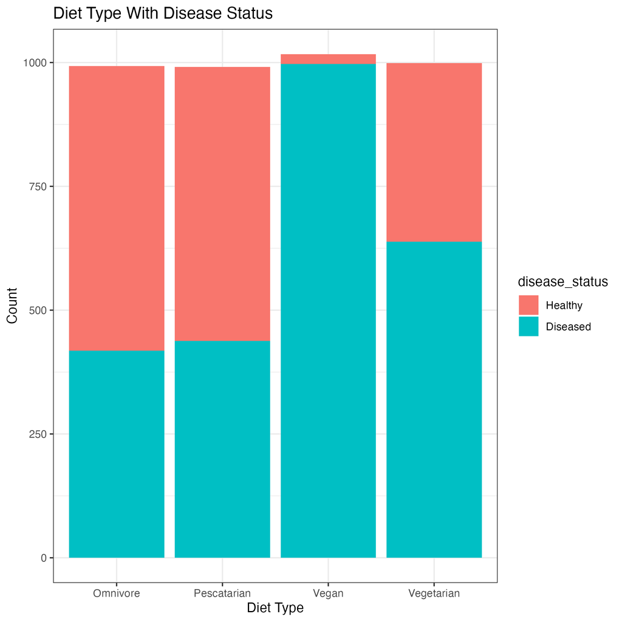

The stacked bar chart above displays the distribution of healthy vs. diseased participants across diet types (Omnivore, Pescatarian, Vegan, Vegetarian). Omnivores and pescatarians show a larger healthy portion relative to diseased portion. In comparison, vegetarians show greater diseased portion relative to healthy individuals; however, vegans show very few healthy individuals, indicating a higher proportion of deficiency-related diseases among vegans.